# Teoría de Probabilidad, Distribuciones y Estadígrafos

Curso de Diseño Experimental y Bioestadística

Francisco E. Fontúrbel

2026-04-03

```r
# Librerías necesarias
library(ggplot2)
library(dplyr)
library(tidyr)
library(patchwork)
library(moments)    # skewness, kurtosis
library(MASS)       # fitdistr

# Tema general para figuras
theme_set(
  theme_bw(base_size = 13) +
    theme(
      panel.grid.minor = element_blank(),
      strip.background = element_rect(fill = "grey90")
    )
)

# Semilla para reproducibilidad
set.seed(2025)
```

# 1 Axiomas y Teoría de Probabilidad

## 1.1 El experimento aleatorio y el espacio muestral

En ecología trabajamos constantemente con fenómenos cuyo resultado no podemos predecir con certeza: ¿llegará un polinizador a una flor en los próximos 10 minutos?, ¿cuántas semillas de *Tristerix corymbosus* serán dispersadas por *Dromiciops gliroides* en una noche? Estos son **experimentos aleatorios**.

Definiciones fundamentales:

- **Experimento aleatorio** ($\mathcal{E}$): un proceso cuyo resultado no se puede predecir con certeza.
- **Espacio muestral** ($\Omega$): el conjunto de todos los resultados posibles.
- **Evento** ($A \subseteq \Omega$): un subconjunto del espacio muestral.

**Ejemplo ecológico:** Observamos un fruto maduro de *T. corymbosus* y registramos si es removido por un ave frugívora en 1 hora.

$$\Omega = \{\text{removido}, \text{no
removido}\}$$

Si observamos 3 frutos simultáneamente:

$$\Omega = \{(r, r, r),\ (r, r, n),\ (r,
n, r),\ \ldots,\ (n, n, n)\}, \quad |\Omega| = 2^3 = 8$$

## 1.2 Axiomas de Kolmogorov (1933)

Sea $\Omega$ un espacio muestral y $\mathcal{F}$ una $\sigma$-álgebra de eventos. Una **función de probabilidad** $P: \mathcal{F} \rightarrow [0, 1]$ satisface:

1. **No negatividad:** $P(A) \geq 0$ para todo $A \in \mathcal{F}$.
2. **Normalización:** $P(\Omega) = 1$.
3. **Aditividad numerable:** Si $A_1, A_2, \ldots$ son mutuamente excluyentes:

$$P\left(\bigcup_{i=1}^{\infty} A_i\right)
= \sum_{i=1}^{\infty} P(A_i)$$

En palabras: (1) las probabilidades nunca son negativas, (2) la probabilidad de que ocurra *algo* es 1, y (3) si dos o más eventos no pueden ocurrir simultáneamente, la probabilidad de que ocurra al menos uno de ellos es simplemente la suma de sus probabilidades individuales. Toda la teoría de probabilidad se construye a partir de estas tres reglas.

### 1.2.1 Consecuencias directas

De estos tres axiomas se derivan propiedades clave:

- $P(\emptyset) = 0$ — lo imposible tiene probabilidad cero.
- $P(A^c) = 1 - P(A)$ — la probabilidad de que un evento *no* ocurra es el complemento de que sí ocurra.
- Si $A \subseteq B$, entonces $P(A) \leq P(B)$ — un evento contenido dentro de otro no puede ser más probable que este.
- $P(A \cup B) = P(A) + P(B) - P(A \cap B)$ — la regla de la suma: al sumar las probabilidades de dos eventos, debemos restar la intersección para no contarla dos veces.

```r
# Simulación: probabilidad de visita de polinizadores
# Supongamos que observamos una planta durante 100 intervalos de 10 min

n_intervalos <- 100
p_visita_abeja <- 0.35
p_visita_colibri <- 0.15
p_ambos <- 0.05  # visita simultánea

# Regla de la suma
p_al_menos_uno <- p_visita_abeja + p_visita_colibri - p_ambos

cat("P(visita de abeja) =", p_visita_abeja, "\n")
```

```
#> P(visita de abeja) = 0.35
```

```r
cat("P(visita de colibrí) =", p_visita_colibri, "\n")
```

```
#> P(visita de colibrí) = 0.15
```

```r
cat("P(ambos) =", p_ambos, "\n")
```

```
#> P(ambos) = 0.05
```

```r
cat("P(al menos un polinizador) =", p_al_menos_uno, "\n")
```

```
#> P(al menos un polinizador) = 0.45
```

```r
cat("P(ningún polinizador) =", 1 - p_al_menos_uno, "\n")
```

```
#> P(ningún polinizador) = 0.55
```

## 1.3 Probabilidad condicional

La probabilidad de un evento $A$ dado que ocurrió $B$:

$$P(A \mid B) = \frac{P(A \cap B)}{P(B)},
\quad P(B) > 0$$

Es decir, si ya sabemos que ocurrió $B$, la probabilidad de $A$ se recalcula considerando solo aquellos casos donde ambos eventos ocurren juntos, dividido por la probabilidad de $B$. Intuitivamente, condicionar es “reducir el universo” al subconjunto donde $B$ ya sucedió.

**Ejemplo ecológico:** En un bosque templado, la probabilidad de detectar a *D. gliroides* en una cámara trampa depende del tipo de hábitat.

```r
# Datos hipotéticos de detección de D. gliroides
# Basados en proporciones típicas de estudios de cámaras trampa

n_noches <- 200

# Tabla de contingencia
deteccion <- matrix(
  c(42, 58, 12, 88),
  nrow = 2, byrow = TRUE,
  dimnames = list(
    Habitat = c("Bosque nativo", "Plantación Eucalyptus"),
    Deteccion = c("Detectado", "No detectado")
  )
)

deteccion
```

```
#>                        Deteccion
#> Habitat                 Detectado No detectado
#>   Bosque nativo                42           58
#>   Plantación Eucalyptus        12           88
```

```r
# P(Detectado | Bosque nativo)
p_det_nativo <- deteccion["Bosque nativo", "Detectado"] /
  sum(deteccion["Bosque nativo", ])

# P(Detectado | Plantación)
p_det_plant <- deteccion["Plantación Eucalyptus", "Detectado"] /
  sum(deteccion["Plantación Eucalyptus", ])

cat("P(Detección | Bosque nativo) =", round(p_det_nativo, 3), "\n")
```

```
#> P(Detección | Bosque nativo) = 0.42
```

```r
cat("P(Detección | Plantación) =", round(p_det_plant, 3), "\n")
```

```
#> P(Detección | Plantación) = 0.12
```

```r
cat("Razón de detección nativo/plantación =",
    round(p_det_nativo / p_det_plant, 2), "\n")
```

```
#> Razón de detección nativo/plantación = 3.5
```

## 1.4 Teorema de Bayes

$$P(A \mid B) = \frac{P(B \mid A) \cdot
P(A)}{P(B)}$$

Donde $P(B)$ se puede expandir por el **teorema de probabilidad total**:

$$P(B) = \sum_{i=1}^{n} P(B \mid A_i)
\cdot P(A_i)$$

Bayes nos permite “invertir” la dirección de una probabilidad condicional: si conocemos la probabilidad de observar cierta evidencia dado cada posible causa, podemos calcular la probabilidad de cada causa dado que observamos esa evidencia. El denominador $P(B)$ actúa como un factor de normalización que se obtiene sumando sobre todas las causas posibles.

### 1.4.1 Aplicación: identificación de dispersores

Supongamos que encontramos una semilla de *T. corymbosus* germinando en una rama. ¿Cuál es la probabilidad de que haya sido depositada por *D. gliroides* versus un ave frugívora?

```r
# Datos basados en literatura
p_dromiciops <- 0.30    # P(dispersor = D. gliroides)
p_ave <- 0.70           # P(dispersor = ave)

# P(semilla viable | dispersor)
p_viable_dromiciops <- 0.85   # D. gliroides: alta viabilidad
p_viable_ave <- 0.40          # Aves: viabilidad moderada

# P(semilla viable) - probabilidad total
p_viable <- p_viable_dromiciops * p_dromiciops +
  p_viable_ave * p_ave

# P(D. gliroides | semilla viable) - Bayes
p_dromiciops_dado_viable <- (p_viable_dromiciops * p_dromiciops) / p_viable

cat("P(semilla viable) =", round(p_viable, 3), "\n")
```

```
#> P(semilla viable) = 0.535
```

```r
cat("P(D. gliroides | semilla viable) =",
    round(p_dromiciops_dado_viable, 3), "\n")
```

```
#> P(D. gliroides | semilla viable) = 0.477
```

```r
cat("P(ave | semilla viable) =",
    round(1 - p_dromiciops_dado_viable, 3), "\n")
```

```
#> P(ave | semilla viable) = 0.523
```

> **Interpretación:** Aunque las aves son responsables del 70% de la dispersión, si encontramos una semilla viable, la probabilidad de que provenga de *D. gliroides* es 47.7%. Esto refleja la mayor efectividad de este marsupial como dispersor legítimo.

## 1.5 Independencia

Dos eventos $A$ y $B$ son **independientes** si y solo si:

$$P(A \cap B) = P(A) \cdot
P(B)$$

Equivalentemente: $P(A \mid B) = P(A)$.

En términos simples, dos eventos son independientes cuando saber que uno ocurrió no cambia en nada la probabilidad del otro. Bajo independencia, la probabilidad conjunta es simplemente el producto de las probabilidades marginales.

En ecología, la independencia es una **asunción fuerte** que rara vez se cumple. La dependencia espacial, temporal y filogenética son la norma en datos ecológicos.

```r
# Test de independencia: visitas de polinizadores
# ¿Son independientes las visitas de abejas y colibríes a Tristerix?

# Datos simulados de visitas en 150 flores
set.seed(42)
n_flores <- 150

visitas <- data.frame(
  abeja = rbinom(n_flores, 1, prob = 0.40),
  colibri = rbinom(n_flores, 1, prob = 0.25)
)

# Introducir dependencia negativa (competencia por recurso)
# Si la abeja visitó, reducimos P(colibrí)
for (i in 1:n_flores) {
  if (visitas$abeja[i] == 1) {
    visitas$colibri[i] <- rbinom(1, 1, prob = 0.10)
  }
}

tabla <- table(
  Abeja = ifelse(visitas$abeja == 1, "Sí", "No"),
  Colibri = ifelse(visitas$colibri == 1, "Sí", "No")
)

tabla
```

```
#>      Colibri
#> Abeja No Sí
#>    No 58 20
#>    Sí 60 12
```

```r
# Test Chi-cuadrado de independencia
test_chi <- chisq.test(tabla)
test_chi
```

```
#>
#>  Pearson's Chi-squared test with Yates' continuity correction
#>
#> data:  tabla
#> X-squared = 1.3018, df = 1, p-value = 0.2539
```

```r
cat("Bajo independencia, P(colibrí | abeja) debería ≈ P(colibrí)\n")
```

```
#> Bajo independencia, P(colibrí | abeja) debería ≈ P(colibrí)
```

```r
cat("P(colibrí) =", round(mean(visitas$colibri), 3), "\n")
```

```
#> P(colibrí) = 0.213
```

```r
cat("P(colibrí | abeja visitó) =",
    round(mean(visitas$colibri[visitas$abeja == 1]), 3), "\n")
```

```
#> P(colibrí | abeja visitó) = 0.167
```

```r
cat("P(colibrí | abeja no visitó) =",
    round(mean(visitas$colibri[visitas$abeja == 0]), 3), "\n")
```

```
#> P(colibrí | abeja no visitó) = 0.256
```

## 1.6 Probabilidades no independientes: cadenas de Markov y métodos de Monte Carlo

En la sección anterior vimos que la independencia es la excepción en ecología. En la práctica, el estado actual de un sistema suele depender de su estado anterior: la ocupación de un parche de hábitat este año depende de si estaba ocupado el año pasado, la probabilidad de que un animal se mueva a un sitio depende de dónde se encuentra ahora, y la composición de una comunidad depende de su historia de ensamblaje. Para modelar este tipo de dependencia secuencial existen las **cadenas de Markov**.

### 1.6.1 Cadenas de Markov

Una cadena de Markov es un proceso estocástico donde la probabilidad de transitar al siguiente estado depende **únicamente del estado actual**, no de la historia completa. Esta es la **propiedad de Markov** (o de “sin memoria”):

$$P(X_{t+1} = j \mid X_t = i, X_{t-1},
\ldots, X_0) = P(X_{t+1} = j \mid X_t = i)$$

En otras palabras, si conocemos el presente, el pasado no aporta información adicional para predecir el futuro. La dinámica completa del sistema queda descrita por una **matriz de transición** $\mathbf{T}$, donde cada elemento $T_{ij}$ representa la probabilidad de pasar del estado $i$ al estado $j$ en un paso de tiempo.

**Ejemplo ecológico:** Modelo de ocupación de parches para *D. gliroides* con tres estados: parche ocupado (O), parche vacío disponible (V) y parche degradado (D).

```r
# Matriz de transición para ocupación de parches
# Filas = estado actual, Columnas = estado siguiente
T_mat <- matrix(
  c(0.75, 0.15, 0.10,   # Desde Ocupado: se mantiene, se vacía, se degrada
    0.30, 0.50, 0.20,   # Desde Vacío: se coloniza, se mantiene, se degrada
    0.05, 0.25, 0.70),  # Desde Degradado: se recupera, mejora, se mantiene
  nrow = 3, byrow = TRUE,
  dimnames = list(
    Desde = c("Ocupado", "Vacío", "Degradado"),
    Hacia = c("Ocupado", "Vacío", "Degradado")
  )
)

knitr::kable(T_mat, digits = 2,
             caption = "Matriz de transición: dinámica de parches de hábitat")
```

Matriz de transición: dinámica de parches de hábitat

|  | Ocupado | Vacío | Degradado |
| --- | --- | --- | --- |
| Ocupado | 0.75 | 0.15 | 0.1 |
| Vacío | 0.30 | 0.50 | 0.2 |
| Degradado | 0.05 | 0.25 | 0.7 |

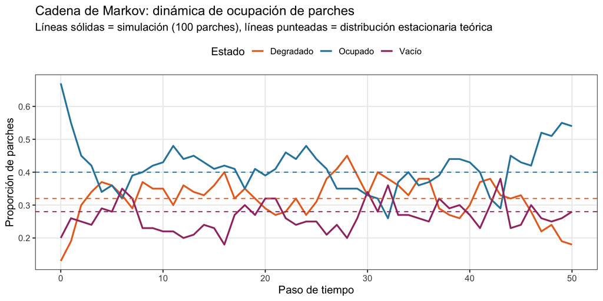

```r
# Simulación de la cadena de Markov por 50 pasos
n_pasos <- 50
n_parches <- 100
estados <- c("Ocupado", "Vacío", "Degradado")

# Estado inicial: 60% ocupado, 25% vacío, 15% degradado
estado_actual <- sample(estados, n_parches, replace = TRUE,
                        prob = c(0.60, 0.25, 0.15))

# Registro de proporciones a lo largo del tiempo
registro <- matrix(NA, nrow = n_pasos + 1, ncol = 3,
                   dimnames = list(NULL, estados))
registro[1, ] <- table(factor(estado_actual, levels = estados)) / n_parches

set.seed(2025)
for (t in 1:n_pasos) {
  nuevo_estado <- character(n_parches)
  for (i in 1:n_parches) {
    fila <- match(estado_actual[i], estados)
    nuevo_estado[i] <- sample(estados, 1, prob = T_mat[fila, ])
  }
  estado_actual <- nuevo_estado
  registro[t + 1, ] <- table(factor(estado_actual, levels = estados)) / n_parches
}

# Distribución estacionaria teórica (autovector izquierdo de T)
autov <- eigen(t(T_mat))
pi_est <- Re(autov$vectors[, 1])
pi_est <- pi_est / sum(pi_est)
names(pi_est) <- estados

# Gráfico
df_markov <- data.frame(
  paso = rep(0:n_pasos, 3),
  proporcion = c(registro[, 1], registro[, 2], registro[, 3]),
  estado = rep(estados, each = n_pasos + 1)
)

ggplot(df_markov, aes(x = paso, y = proporcion, color = estado)) +
  geom_line(linewidth = 1) +
  geom_hline(data = data.frame(estado = estados, y = pi_est),
             aes(yintercept = y, color = estado),
             linetype = "dashed", linewidth = 0.6) +
  scale_color_manual(values = c("Degradado" = "#E8702A",
                                "Ocupado" = "#2E86AB",
                                "Vacío" = "#A23B72")) +
  labs(
    title = "Cadena de Markov: dinámica de ocupación de parches",
    subtitle = "Líneas sólidas = simulación (100 parches), líneas punteadas = distribución estacionaria teórica",
    x = "Paso de tiempo", y = "Proporción de parches",
    color = "Estado"
  ) +
  theme(legend.position = "top")
```

```r
cat("Distribución estacionaria (π):\n")
```

```
#> Distribución estacionaria (π):
```

```r
cat(paste0("  ", estados, ": ", round(pi_est, 3), collapse = "\n"), "\n\n")
```

```
#>   Ocupado: 0.4
#>   Vacío: 0.28
#>   Degradado: 0.32
```

```r
cat("A largo plazo, sin importar el estado inicial, el sistema converge\n")
```

```
#> A largo plazo, sin importar el estado inicial, el sistema converge
```

```r
cat("a estas proporciones de equilibrio.\n")
```

```
#> a estas proporciones de equilibrio.
```

Una propiedad fundamental de las cadenas de Markov ergódicas (irreducibles y aperiódicas) es que convergen a una **distribución estacionaria** $\boldsymbol{\pi}$ que no depende del estado inicial. Esto es precisamente lo que aprovechan los métodos de Monte Carlo.

### 1.6.2 Métodos de Monte Carlo basados en cadenas de Markov (MCMC)

Los métodos **MCMC** combinan las cadenas de Markov con el muestreo de Monte Carlo para extraer muestras de distribuciones de probabilidad complejas, típicamente distribuciones posteriores bayesianas que no tienen solución analítica.

La idea central es construir una cadena de Markov cuya distribución estacionaria sea exactamente la distribución objetivo $p(\theta \mid \text{datos})$. Al dejar correr la cadena suficiente tiempo, las muestras generadas son representativas de la distribución posterior, y podemos usarlas para estimar parámetros, intervalos de credibilidad, y hacer predicciones.

Los algoritmos más utilizados son:

- **Metropolis-Hastings**: propone un salto aleatorio y lo acepta o rechaza según una razón de probabilidades. Es general pero puede ser lento en espacios de alta dimensión.
- **Muestreo de Gibbs**: caso especial donde se muestrean las condicionales completas de cada parámetro por turno. Es eficiente cuando esas condicionales tienen forma conocida.
- **Hamiltonian Monte Carlo (HMC)**: utiliza información del gradiente para proponer saltos más eficientes. Es el motor detrás de Stan y `brms`.

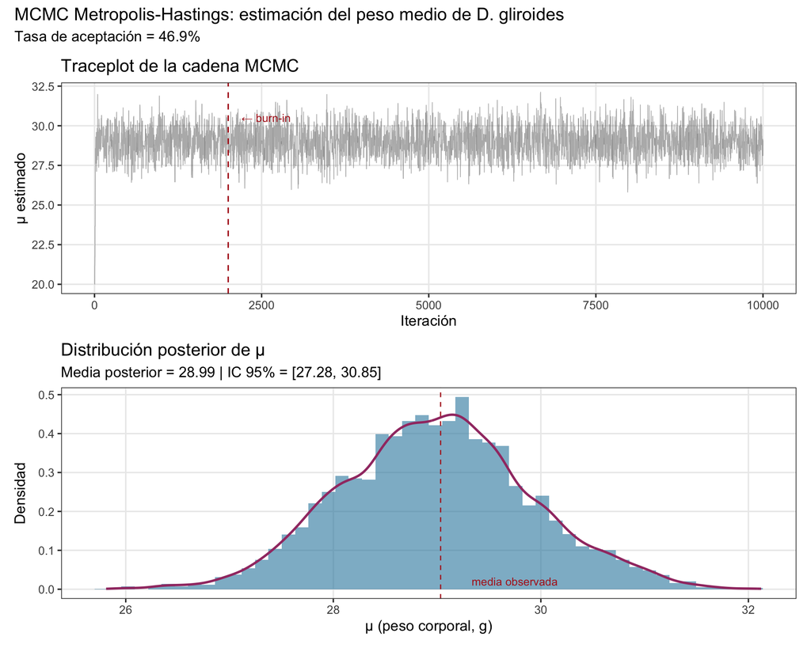

```r
# Demostración simplificada de Metropolis-Hastings
# Estimación de la media del peso de D. gliroides
# Asumimos prior Normal(25, 10) y likelihood Normal(mu, sigma=5)

set.seed(2025)
datos_peso_obs <- rnorm(30, mean = 28, sd = 5)  # datos observados

# Funciones
log_posterior <- function(mu, datos, prior_mu = 25, prior_sd = 10, sigma = 5) {
  log_lik <- sum(dnorm(datos, mean = mu, sd = sigma, log = TRUE))
  log_prior <- dnorm(mu, mean = prior_mu, sd = prior_sd, log = TRUE)
  log_lik + log_prior
}

# Metropolis-Hastings
n_iter <- 10000
cadena <- numeric(n_iter)
cadena[1] <- 20  # valor inicial alejado del óptimo
propuesta_sd <- 2
aceptados <- 0

for (i in 2:n_iter) {
  propuesta <- rnorm(1, mean = cadena[i - 1], sd = propuesta_sd)
  log_ratio <- log_posterior(propuesta, datos_peso_obs) -
    log_posterior(cadena[i - 1], datos_peso_obs)

  if (log(runif(1)) < log_ratio) {
    cadena[i] <- propuesta
    aceptados <- aceptados + 1
  } else {
    cadena[i] <- cadena[i - 1]
  }
}

# Descartar burn-in
burnin <- 2000
muestras_post <- cadena[(burnin + 1):n_iter]

# Gráficos de diagnóstico
df_cadena <- data.frame(
  iteracion = 1:n_iter,
  mu = cadena
)

p_trace <- ggplot(df_cadena, aes(iteracion, mu)) +
  geom_line(alpha = 0.5, color = "grey40", linewidth = 0.3) +
  geom_vline(xintercept = burnin, linetype = "dashed",
             color = "firebrick", linewidth = 0.6) +
  annotate("text", x = burnin + 200, y = max(cadena) * 0.95,
           label = "← burn-in", color = "firebrick", hjust = 0, size = 3.5) +
  labs(title = "Traceplot de la cadena MCMC",
       x = "Iteración", y = "μ estimado")

p_post <- ggplot(data.frame(mu = muestras_post), aes(mu)) +
  geom_histogram(aes(y = after_stat(density)),
                 bins = 50, fill = "#2E86AB", alpha = 0.6) +
  geom_density(color = "#A23B72", linewidth = 1) +
  geom_vline(xintercept = mean(datos_peso_obs),
             linetype = "dashed", color = "firebrick") +
  annotate("text", x = mean(datos_peso_obs) + 0.3,
           y = 0, label = "media observada",
           color = "firebrick", hjust = 0, vjust = -0.5, size = 3.5) +
  labs(title = "Distribución posterior de μ",
       subtitle = paste0("Media posterior = ",
                         round(mean(muestras_post), 2),
                         " | IC 95% = [",
                         round(quantile(muestras_post, 0.025), 2), ", ",
                         round(quantile(muestras_post, 0.975), 2), "]"),
       x = "μ (peso corporal, g)", y = "Densidad")

p_trace / p_post +
  plot_annotation(
    title = "MCMC Metropolis-Hastings: estimación del peso medio de D. gliroides",
    subtitle = paste0("Tasa de aceptación = ",
                      round(aceptados / n_iter * 100, 1), "%")
  )
```

```r
cat("Resumen de la distribución posterior:\n")
```

```
#> Resumen de la distribución posterior:
```

```r
cat("  Media posterior:", round(mean(muestras_post), 3), "\n")
```

```
#>   Media posterior: 28.991
```

```r
cat("  Mediana posterior:", round(median(muestras_post), 3), "\n")
```

```
#>   Mediana posterior: 28.996
```

```r
cat("  DE posterior:", round(sd(muestras_post), 3), "\n")
```

```
#>   DE posterior: 0.912
```

```r
cat("  IC 95%: [", round(quantile(muestras_post, 0.025), 3), ",",
    round(quantile(muestras_post, 0.975), 3), "]\n")
```

```
#>   IC 95%: [ 27.276 , 30.851 ]
```

```r
cat("  Tasa de aceptación:", round(aceptados / n_iter * 100, 1), "%\n\n")
```

```
#>   Tasa de aceptación: 46.9 %
```

```r
cat("Nota: una tasa de aceptación entre 20-50% es generalmente\n")
```

```
#> Nota: una tasa de aceptación entre 20-50% es generalmente
```

```r
cat("deseable para Metropolis-Hastings en una dimensión.\n")
```

```
#> deseable para Metropolis-Hastings en una dimensión.
```

> **¿Por qué importa para ecólogos?** MCMC es el motor computacional detrás de los modelos bayesianos que usamos cotidianamente: `MCMCglmm`, `brms`, `JAGS`, `Stan`, y los modelos de ocupación (`unmarked`, `ubms`). Cada vez que ajustamos uno de estos modelos, internamente se está ejecutando una cadena de Markov que converge a la distribución posterior de los parámetros. Entender sus fundamentos nos permite diagnosticar problemas de convergencia e interpretar correctamente los resultados.

# 2 Distribuciones de Probabilidad

## 2.1 Variables aleatorias

Una **variable aleatoria** $X$ es una función que asigna un valor numérico a cada resultado del espacio muestral: $X: \Omega \rightarrow \mathbb{R}$.

- **Discreta:** toma valores contables (conteos de individuos, número de semillas).
- **Continua:** toma cualquier valor en un intervalo (biomasa, longitud corporal, temperatura).

## 2.2 Distribuciones discretas

### 2.2.1 Bernoulli y Binomial

Si cada ensayo tiene probabilidad $p$ de éxito, y realizamos $n$ ensayos independientes:

$$X \sim \text{Binomial}(n, p), \quad P(X
= k) = \binom{n}{k} p^k (1-p)^{n-k}$$

- $E[X] = np$
- $\text{Var}(X) = np(1-p)$

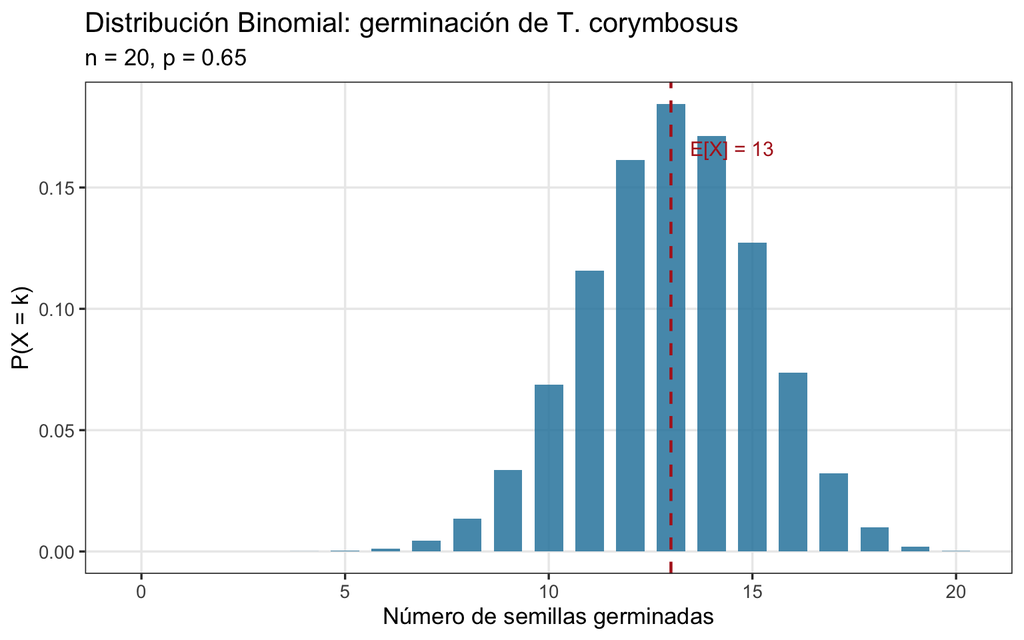

```r
# Ejemplo: germinación de semillas de T. corymbosus
# Experimento: 20 semillas, P(germinación) = 0.65

n_semillas <- 20
p_germ <- 0.65
x <- 0:n_semillas

prob_binom <- dbinom(x, size = n_semillas, prob = p_germ)

p1 <- ggplot(data.frame(x, prob = prob_binom), aes(x, prob)) +
  geom_col(fill = "#2E86AB", width = 0.7, alpha = 0.85) +
  geom_vline(xintercept = n_semillas * p_germ,
             linetype = "dashed", color = "firebrick", linewidth = 0.8) +
  annotate("text", x = n_semillas * p_germ + 1.5,
           y = max(prob_binom) * 0.9,
           label = paste0("E[X] = ", n_semillas * p_germ),
           color = "firebrick", size = 4) +
  labs(
    title = "Distribución Binomial: germinación de T. corymbosus",
    subtitle = paste0("n = ", n_semillas, ", p = ", p_germ),
    x = "Número de semillas germinadas",
    y = "P(X = k)"
  )

p1
```

### 2.2.2 Poisson

Modela conteos de eventos raros en un intervalo fijo. Si $\lambda$ es la tasa media:

$$X \sim \text{Poisson}(\lambda), \quad
P(X = k) = \frac{e^{-\lambda} \lambda^k}{k!}$$

- $E[X] = \lambda$
- $\text{Var}(X) = \lambda$ (equidispersión)

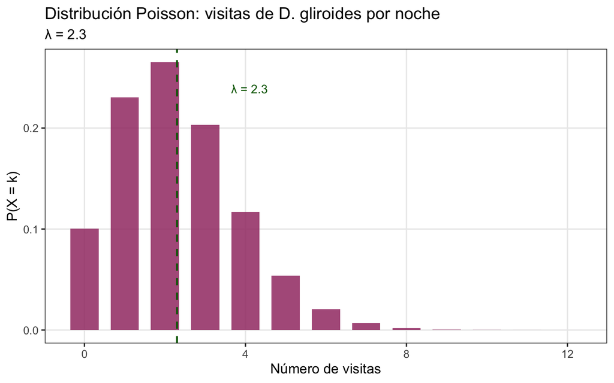

```r
# Ejemplo: conteo de visitas de D. gliroides por cámara-trampa por noche
lambda_visitas <- 2.3
x_pois <- 0:12

prob_pois <- dpois(x_pois, lambda = lambda_visitas)

p2 <- ggplot(data.frame(x = x_pois, prob = prob_pois), aes(x, prob)) +
  geom_col(fill = "#A23B72", width = 0.7, alpha = 0.85) +
  geom_vline(xintercept = lambda_visitas,
             linetype = "dashed", color = "darkgreen", linewidth = 0.8) +
  annotate("text", x = lambda_visitas + 1.8,
           y = max(prob_pois) * 0.9,
           label = paste0("λ = ", lambda_visitas),
           color = "darkgreen", size = 4) +
  labs(
    title = "Distribución Poisson: visitas de D. gliroides por noche",
    subtitle = paste0("λ = ", lambda_visitas),
    x = "Número de visitas",
    y = "P(X = k)"
  )

p2
```

### 2.2.3 Binomial Negativa

Cuando hay **sobredispersión** ($\text{Var}(X) > E[X]$), la Poisson no es adecuada. La binomial negativa añade un parámetro de dispersión $\theta$ (o $k$):

$$\text{Var}(X) = \mu +
\frac{\mu^2}{\theta}$$

Cuando $\theta \rightarrow \infty$, converge a Poisson.

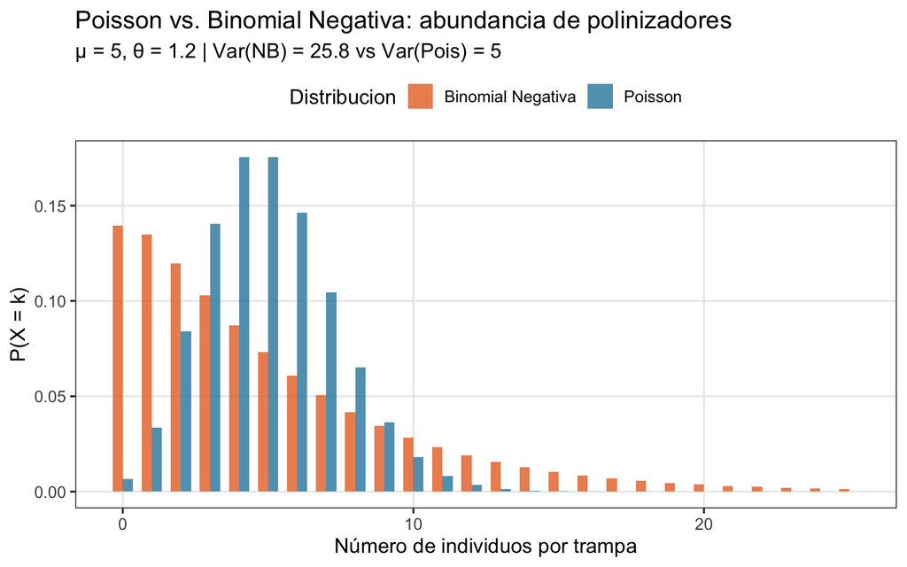

```r
# Ejemplo: abundancia de insectos polinizadores por trampa (sobredispersión)
mu_insectos <- 5
theta_val <- 1.2  # sobredispersión fuerte

x_nb <- 0:25

prob_nb <- dnbinom(x_nb, mu = mu_insectos, size = theta_val)
prob_pois_comp <- dpois(x_nb, lambda = mu_insectos)

df_comp <- data.frame(
  x = rep(x_nb, 2),
  prob = c(prob_nb, prob_pois_comp),
  Distribucion = rep(c("Binomial Negativa", "Poisson"), each = length(x_nb))
)

p3 <- ggplot(df_comp, aes(x, prob, fill = Distribucion)) +
  geom_col(position = "dodge", width = 0.7, alpha = 0.8) +
  scale_fill_manual(values = c("#E8702A", "#2E86AB")) +
  labs(
    title = "Poisson vs. Binomial Negativa: abundancia de polinizadores",
    subtitle = paste0("μ = ", mu_insectos,
                      ", θ = ", theta_val,
                      " | Var(NB) = ",
                      round(mu_insectos + mu_insectos^2 / theta_val, 1),
                      " vs Var(Pois) = ", mu_insectos),
    x = "Número de individuos por trampa",
    y = "P(X = k)"
  ) +
  theme(legend.position = "top")

p3
```

> **Nota para ecólogos:** La sobredispersión es *la regla* en datos de abundancia ecológica. Siempre evalúen la relación media-varianza antes de asumir Poisson. La función `glm.nb()` de `MASS` o `glmmTMB()` son alternativas robustas.

## 2.3 Distribuciones continuas

### 2.3.1 Normal (Gaussiana)

$$X \sim \mathcal{N}(\mu, \sigma^2), \quad
f(x) = \frac{1}{\sigma\sqrt{2\pi}}
\exp\left(-\frac{(x-\mu)^2}{2\sigma^2}\right)$$

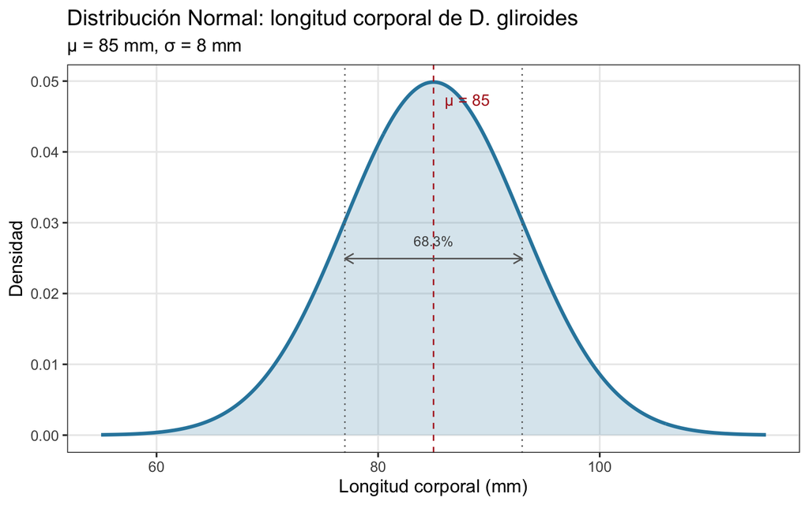

```r
# Ejemplo: longitud corporal de D. gliroides (mm)
mu_lc <- 85    # media en mm
sigma_lc <- 8  # desviación estándar

x_norm <- seq(55, 115, length.out = 300)

df_norm <- data.frame(
  x = x_norm,
  densidad = dnorm(x_norm, mean = mu_lc, sd = sigma_lc)
)

p4 <- ggplot(df_norm, aes(x, densidad)) +
  geom_line(color = "#2E86AB", linewidth = 1.2) +
  geom_area(alpha = 0.2, fill = "#2E86AB") +
  geom_vline(xintercept = mu_lc, linetype = "dashed", color = "firebrick") +
  geom_vline(xintercept = c(mu_lc - sigma_lc, mu_lc + sigma_lc),
             linetype = "dotted", color = "grey40") +
  annotate("text", x = mu_lc + 1, y = max(df_norm$densidad) * 0.95,
           label = paste0("μ = ", mu_lc), color = "firebrick",
           hjust = 0, size = 4) +
  annotate("segment",
           x = mu_lc - sigma_lc, xend = mu_lc + sigma_lc,
           y = max(df_norm$densidad) * 0.5,
           yend = max(df_norm$densidad) * 0.5,
           arrow = arrow(ends = "both", length = unit(0.1, "inches")),
           color = "grey40") +
  annotate("text", x = mu_lc, y = max(df_norm$densidad) * 0.55,
           label = "68.3%", color = "grey30", size = 3.5) +
  labs(
    title = "Distribución Normal: longitud corporal de D. gliroides",
    subtitle = paste0("μ = ", mu_lc, " mm, σ = ", sigma_lc, " mm"),
    x = "Longitud corporal (mm)",
    y = "Densidad"
  )

p4
```

### 2.3.2 Log-Normal

Si $\ln(X) \sim \mathcal{N}(\mu, \sigma^2)$, entonces $X$ sigue una distribución log-normal. Muy común en ecología para variables positivas con asimetría derecha (biomasa, área de distribución, tamaño poblacional).

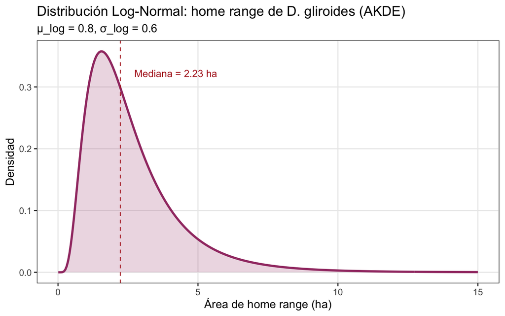

```r
# Ejemplo: área de home range de D. gliroides (ha) estimada por AKDE
mu_log <- 0.8
sigma_log <- 0.6

x_ln <- seq(0.01, 15, length.out = 300)

df_ln <- data.frame(
  x = x_ln,
  densidad = dlnorm(x_ln, meanlog = mu_log, sdlog = sigma_log)
)

p5 <- ggplot(df_ln, aes(x, densidad)) +
  geom_line(color = "#A23B72", linewidth = 1.2) +
  geom_area(alpha = 0.2, fill = "#A23B72") +
  geom_vline(xintercept = exp(mu_log), linetype = "dashed",
             color = "firebrick") +
  annotate("text", x = exp(mu_log) + 0.5,
           y = max(df_ln$densidad) * 0.9,
           label = paste0("Mediana = ", round(exp(mu_log), 2), " ha"),
           color = "firebrick", hjust = 0, size = 4) +
  labs(
    title = "Distribución Log-Normal: home range de D. gliroides (AKDE)",
    subtitle = paste0("μ_log = ", mu_log, ", σ_log = ", sigma_log),
    x = "Área de home range (ha)",
    y = "Densidad"
  )

p5
```

### 2.3.3 Gamma

Útil para modelar tiempos de espera o variables positivas continuas con asimetría variable:

$$X \sim \text{Gamma}(\alpha, \beta),
\quad E[X] = \alpha/\beta, \quad \text{Var}(X) =
\alpha/\beta^2$$

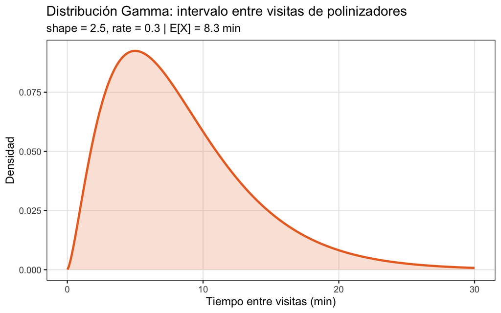

```r
# Ejemplo: tiempo entre visitas sucesivas de polinizadores (minutos)
shape_val <- 2.5
rate_val <- 0.3

x_gam <- seq(0.01, 30, length.out = 300)

df_gam <- data.frame(
  x = x_gam,
  densidad = dgamma(x_gam, shape = shape_val, rate = rate_val)
)

p6 <- ggplot(df_gam, aes(x, densidad)) +
  geom_line(color = "#E8702A", linewidth = 1.2) +
  geom_area(alpha = 0.2, fill = "#E8702A") +
  labs(
    title = "Distribución Gamma: intervalo entre visitas de polinizadores",
    subtitle = paste0("shape = ", shape_val, ", rate = ", rate_val,
                      " | E[X] = ", round(shape_val / rate_val, 1), " min"),
    x = "Tiempo entre visitas (min)",
    y = "Densidad"
  )

p6
```

### 2.3.4 Beta

Modela proporciones y probabilidades ($X \in [0, 1]$):

$$X \sim \text{Beta}(\alpha, \beta), \quad
E[X] = \frac{\alpha}{\alpha + \beta}$$

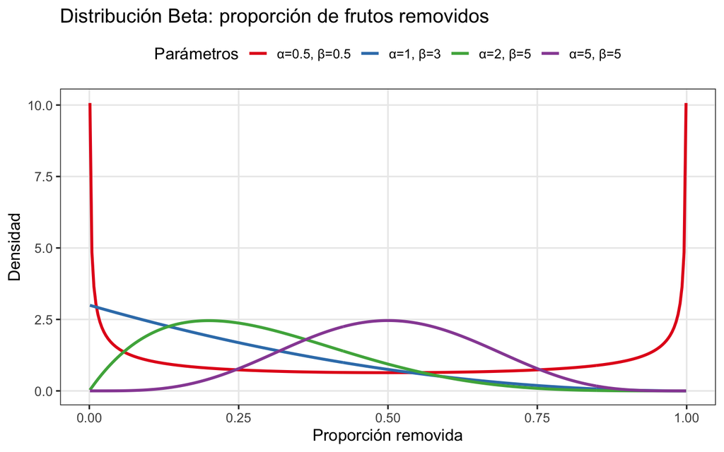

```r
# Ejemplo: proporción de frutos removidos por sitio
alphas <- c(2, 5, 1, 0.5)
betas  <- c(5, 5, 3, 0.5)

x_beta <- seq(0.001, 0.999, length.out = 300)

df_beta <- purrr::map2_dfr(alphas, betas, function(a, b) {
  data.frame(
    x = x_beta,
    densidad = dbeta(x_beta, a, b),
    params = paste0("α=", a, ", β=", b)
  )
})

p7 <- ggplot(df_beta, aes(x, densidad, color = params)) +
  geom_line(linewidth = 1.1) +
  scale_color_brewer(palette = "Set1") +
  labs(
    title = "Distribución Beta: proporción de frutos removidos",
    x = "Proporción removida",
    y = "Densidad",
    color = "Parámetros"
  ) +
  theme(legend.position = "top")

p7
```

## 2.4 Panel comparativo de distribuciones

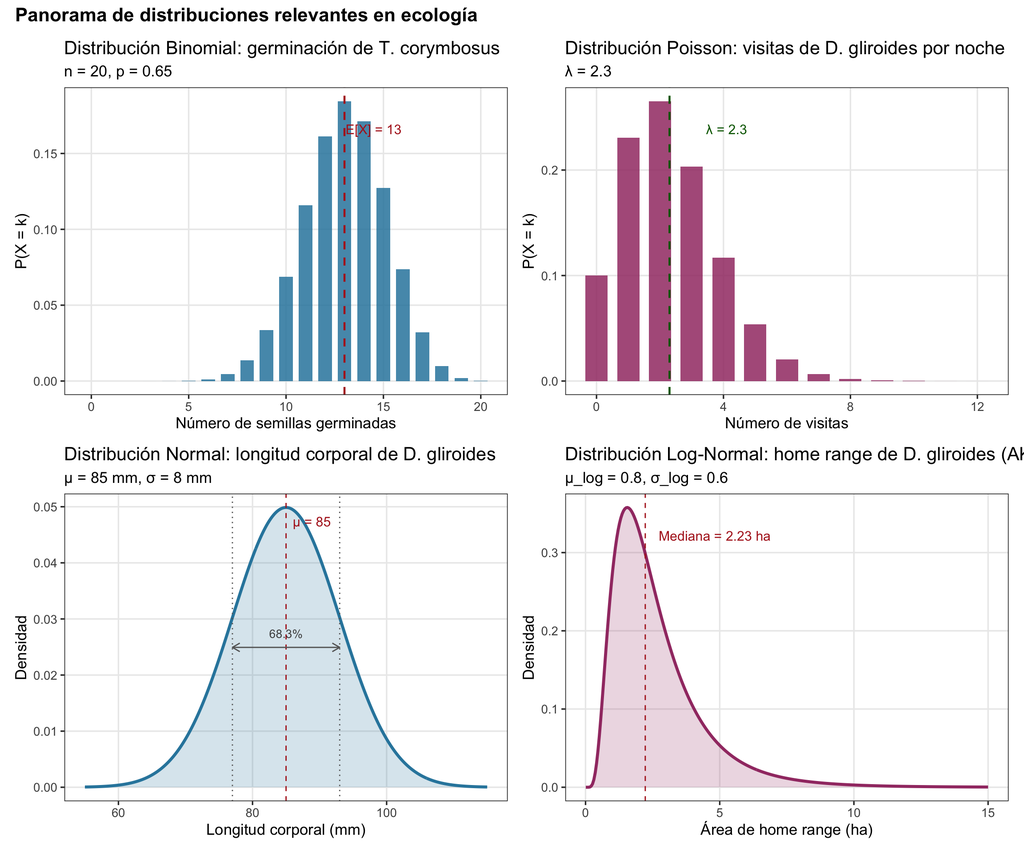

```r
(p1 + p2) / (p4 + p5) +
  plot_annotation(
    title = "Panorama de distribuciones relevantes en ecología",
    theme = theme(plot.title = element_text(size = 16, face = "bold"))
  )
```

## 2.5 ¿Cómo elegir la distribución adecuada?

```r
tabla_dist <- data.frame(
  Distribución = c("Binomial", "Poisson", "Binomial Neg.",
                    "Normal", "Log-Normal", "Gamma", "Beta"),
  Tipo = c("Discreta", "Discreta", "Discreta",
           "Continua", "Continua", "Continua", "Continua"),
  Soporte = c("{0,...,n}", "{0,1,2,...}", "{0,1,2,...}",
              "(-∞, +∞)", "(0, +∞)", "(0, +∞)", "(0, 1)"),
  `Uso ecológico` = c(
    "Presencia/ausencia, germinación, éxito reproductivo",
    "Conteos de individuos, eventos raros (equidispersión)",
    "Conteos sobredispersos (abundancia, parásitos)",
    "Medidas morfométricas, rasgos continuos simétricos",
    "Biomasa, área, tamaño poblacional, home range",
    "Tiempos de espera, precipitación, concentraciones",
    "Proporciones, cobertura vegetal, tasas de remoción"
  ),
  `Relación media-varianza` = c(
    "Var < μ (subdispersión posible)",
    "Var = μ",
    "Var > μ (sobredispersión)",
    "Var independiente de μ",
    "Var crece con μ",
    "Var crece con μ²",
    "Var depende de α y β"
  )
)

knitr::kable(tabla_dist, caption = "Guía para selección de distribuciones")
```

Guía para selección de distribuciones

| Distribución | Tipo | Soporte | Uso.ecológico | Relación.media.varianza |
| --- | --- | --- | --- | --- |
| Binomial | Discreta | {0,…,n} | Presencia/ausencia, germinación, éxito reproductivo | Var < μ (subdispersión posible) |
| Poisson | Discreta | {0,1,2,…} | Conteos de individuos, eventos raros (equidispersión) | Var = μ |
| Binomial Neg. | Discreta | {0,1,2,…} | Conteos sobredispersos (abundancia, parásitos) | Var > μ (sobredispersión) |
| Normal | Continua | (-∞, +∞) | Medidas morfométricas, rasgos continuos simétricos | Var independiente de μ |
| Log-Normal | Continua | (0, +∞) | Biomasa, área, tamaño poblacional, home range | Var crece con μ |
| Gamma | Continua | (0, +∞) | Tiempos de espera, precipitación, concentraciones | Var crece con μ² |
| Beta | Continua | (0, 1) | Proporciones, cobertura vegetal, tasas de remoción | Var depende de α y β |

# 3 Estadígrafos Descriptivos

Los estadígrafos son funciones de los datos muestrales que resumen información clave de la distribución subyacente. Se organizan en tres familias principales.

## 3.1 Medidas de tendencia central

```r
# Datos simulados: peso corporal de D. gliroides (g)
# Dos poblaciones: bosque nativo vs. borde de plantación
set.seed(123)

peso_nativo <- rnorm(45, mean = 28, sd = 4.5)
peso_borde  <- c(rnorm(35, mean = 24, sd = 5), rnorm(10, mean = 38, sd = 3))

datos_peso <- data.frame(
  peso = c(peso_nativo, peso_borde),
  habitat = rep(c("Bosque nativo", "Borde plantación"),
                c(length(peso_nativo), length(peso_borde)))
)
```

### 3.1.1 Media aritmética, mediana y moda

$$\bar{x} = \frac{1}{n}\sum_{i=1}^{n}
x_i$$

La **mediana** ($\tilde{x}$) es el valor que divide la distribución en dos mitades iguales. Es más robusta a valores extremos.

```r
resumen_tc <- datos_peso %>%
  group_by(habitat) %>%
  summarise(
    n = n(),
    media = round(mean(peso), 2),
    mediana = round(median(peso), 2),
    media_recortada_10 = round(mean(peso, trim = 0.10), 2),
    .groups = "drop"
  )

knitr::kable(resumen_tc,
             caption = "Medidas de tendencia central del peso de D. gliroides")
```

Medidas de tendencia central del peso de D. gliroides

| habitat | n | media | mediana | media_recortada_10 |
| --- | --- | --- | --- | --- |
| Borde plantación | 45 | 27.16 | 25.08 | 26.89 |
| Bosque nativo | 45 | 28.30 | 28.32 | 28.24 |

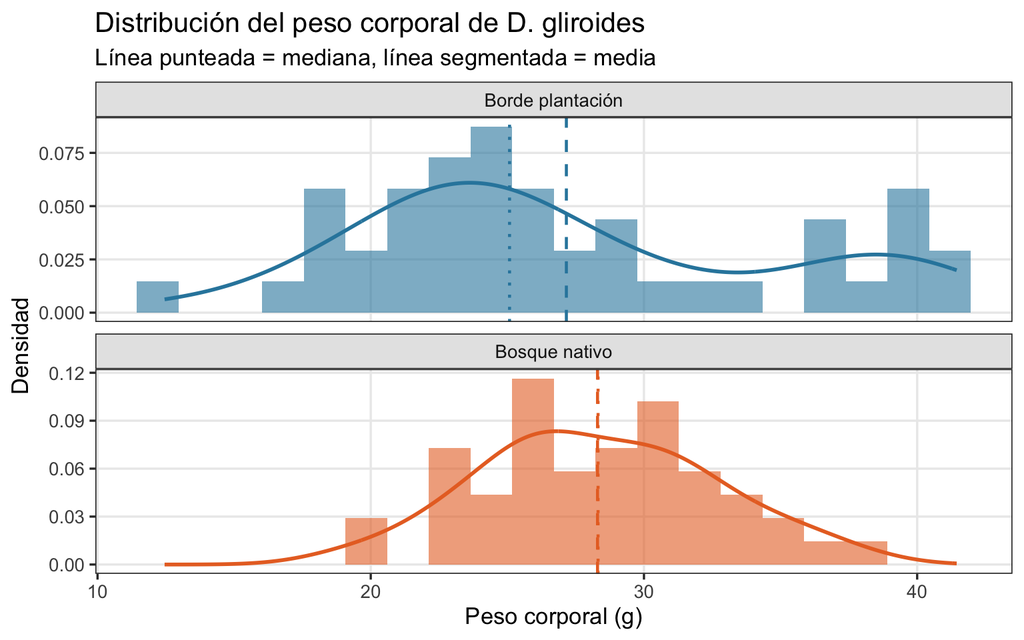

```r
ggplot(datos_peso, aes(x = peso, fill = habitat)) +
  geom_histogram(aes(y = after_stat(density)),
                 bins = 20, alpha = 0.6, position = "identity") +
  geom_density(aes(color = habitat), linewidth = 1, fill = NA) +
  geom_vline(data = resumen_tc,
             aes(xintercept = media, color = habitat),
             linetype = "dashed", linewidth = 0.8) +
  geom_vline(data = resumen_tc,
             aes(xintercept = mediana, color = habitat),
             linetype = "dotted", linewidth = 0.8) +
  scale_fill_manual(values = c("#2E86AB", "#E8702A")) +
  scale_color_manual(values = c("#2E86AB", "#E8702A")) +
  facet_wrap(~habitat, ncol = 1, scales = "free_y") +
  labs(
    title = "Distribución del peso corporal de D. gliroides",
    subtitle = "Línea punteada = mediana, línea segmentada = media",
    x = "Peso corporal (g)",
    y = "Densidad"
  ) +
  theme(legend.position = "none")
```

> **Punto clave:** Cuando media ≠ mediana, la distribución es asimétrica. La diferencia entre ambas indica el grado y dirección de la asimetría.

## 3.2 Medidas de dispersión

### 3.2.1 Varianza, desviación estándar y coeficiente de variación

$$s^2 = \frac{1}{n-1}\sum_{i=1}^{n}(x_i -
\bar{x})^2, \quad s = \sqrt{s^2}, \quad CV = \frac{s}{\bar{x}} \times
100$$

### 3.2.2 Rango intercuartílico (IQR) y MAD

El **IQR** = $Q_3 - Q_1$ y la **MAD** (median absolute deviation) son alternativas robustas.

```r
resumen_disp <- datos_peso %>%
  group_by(habitat) %>%
  summarise(
    varianza = round(var(peso), 2),
    DE = round(sd(peso), 2),
    CV_pct = round(sd(peso) / mean(peso) * 100, 1),
    IQR = round(IQR(peso), 2),
    MAD = round(mad(peso), 2),
    rango = round(diff(range(peso)), 2),
    .groups = "drop"
  )

knitr::kable(resumen_disp,
             caption = "Medidas de dispersión del peso de D. gliroides")
```

Medidas de dispersión del peso de D. gliroides

| habitat | varianza | DE | CV_pct | IQR | MAD | rango |
| --- | --- | --- | --- | --- | --- | --- |
| Borde plantación | 56.79 | 7.54 | 27.8 | 9.60 | 5.85 | 28.99 |
| Bosque nativo | 18.23 | 4.27 | 15.1 | 5.68 | 4.21 | 18.61 |

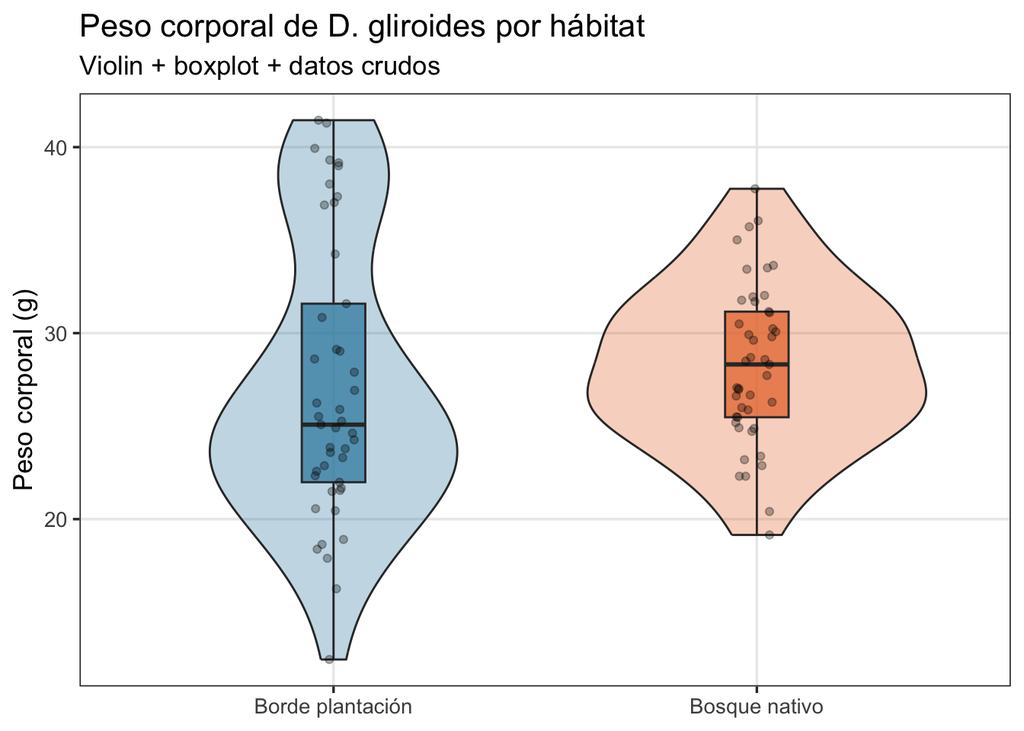

```r
ggplot(datos_peso, aes(x = habitat, y = peso, fill = habitat)) +
  geom_violin(alpha = 0.3, width = 0.8) +
  geom_boxplot(width = 0.15, outlier.shape = 21,
               outlier.fill = "firebrick", alpha = 0.7) +
  geom_jitter(width = 0.05, alpha = 0.3, size = 1.5) +
  scale_fill_manual(values = c("#2E86AB", "#E8702A")) +
  labs(
    title = "Peso corporal de D. gliroides por hábitat",
    subtitle = "Violin + boxplot + datos crudos",
    x = NULL, y = "Peso corporal (g)"
  ) +
  theme(legend.position = "none")
```

## 3.3 Medidas de forma

### 3.3.1 Asimetría (skewness)

$$g_1 = \frac{n}{(n-1)(n-2)}
\sum_{i=1}^{n}\left(\frac{x_i - \bar{x}}{s}\right)^3$$

- $g_1 = 0$: simétrica
- $g_1 > 0$: cola derecha (positiva)
- $g_1 < 0$: cola izquierda (negativa)

### 3.3.2 Curtosis (kurtosis)

$$g_2 = \frac{n(n+1)}{(n-1)(n-2)(n-3)}
\sum_{i=1}^{n}\left(\frac{x_i - \bar{x}}{s}\right)^4 -
\frac{3(n-1)^2}{(n-2)(n-3)}$$

- $g_2 = 0$: mesocúrtica (como la normal)
- $g_2 > 0$: leptocúrtica (colas pesadas)
- $g_2 < 0$: platicúrtica (colas livianas)

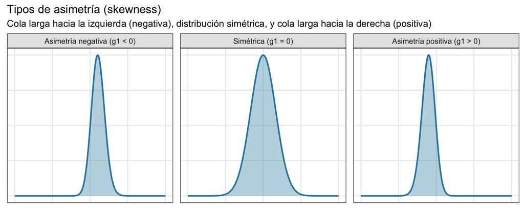

```r
# Figura ilustrativa de asimetría (skewness)
x_seq <- seq(-6, 6, length.out = 500)

df_skew <- rbind(
  data.frame(
    x = x_seq,
    densidad = dbeta(pnorm(x_seq), 5, 2) * dnorm(x_seq),
    tipo = "Asimetría negativa (g1 < 0)"
  ),
  data.frame(
    x = x_seq,
    densidad = dnorm(x_seq, 0, 1),
    tipo = "Simétrica (g1 = 0)"
  ),
  data.frame(
    x = x_seq,
    densidad = dbeta(pnorm(x_seq), 2, 5) * dnorm(x_seq),
    tipo = "Asimetría positiva (g1 > 0)"
  )
)

# Normalizar cada panel para que se vean como densidades
df_skew <- df_skew %>%
  group_by(tipo) %>%
  mutate(densidad = densidad / max(densidad)) %>%
  ungroup()

df_skew$tipo <- factor(df_skew$tipo,
                        levels = c("Asimetría negativa (g1 < 0)",
                                   "Simétrica (g1 = 0)",
                                   "Asimetría positiva (g1 > 0)"))

ggplot(df_skew, aes(x, densidad)) +
  geom_area(fill = "#2E86AB", alpha = 0.35) +
  geom_line(color = "#2E86AB", linewidth = 1) +
  facet_wrap(~tipo, scales = "free_y") +
  labs(
    title = "Tipos de asimetría (skewness)",
    subtitle = "Cola larga hacia la izquierda (negativa), distribución simétrica, y cola larga hacia la derecha (positiva)",
    x = NULL, y = NULL
  ) +
  theme(axis.text = element_blank(), axis.ticks = element_blank())
```

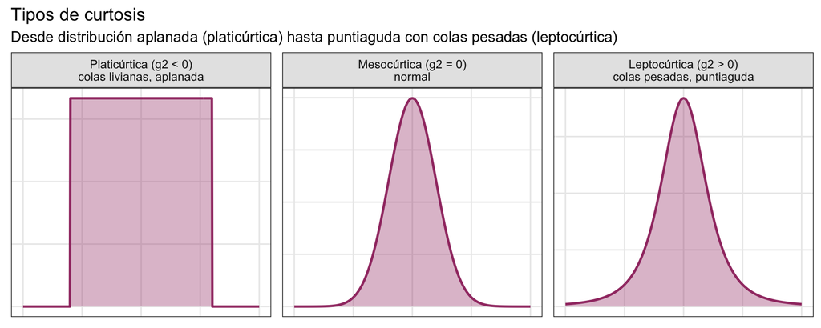

```r
# Figura ilustrativa de curtosis
x_seq2 <- seq(-5, 5, length.out = 500)

df_kurt <- rbind(
  data.frame(
    x = x_seq2,
    densidad = dunif(x_seq2, -3, 3),
    tipo = "Platicúrtica (g2 < 0)\ncolas livianas, aplanada"
  ),
  data.frame(
    x = x_seq2,
    densidad = dnorm(x_seq2, 0, 1),
    tipo = "Mesocúrtica (g2 = 0)\nnormal"
  ),
  data.frame(
    x = x_seq2,
    densidad = dt(x_seq2, df = 3),
    tipo = "Leptocúrtica (g2 > 0)\ncolas pesadas, puntiaguda"
  )
)

df_kurt$tipo <- factor(df_kurt$tipo,
                        levels = c(
                          "Platicúrtica (g2 < 0)\ncolas livianas, aplanada",
                          "Mesocúrtica (g2 = 0)\nnormal",
                          "Leptocúrtica (g2 > 0)\ncolas pesadas, puntiaguda"))

ggplot(df_kurt, aes(x, densidad)) +
  geom_area(fill = "#A23B72", alpha = 0.35) +
  geom_line(color = "#A23B72", linewidth = 1) +
  facet_wrap(~tipo, scales = "free_y") +
  labs(
    title = "Tipos de curtosis",
    subtitle = "Desde distribución aplanada (platicúrtica) hasta puntiaguda con colas pesadas (leptocúrtica)",
    x = NULL, y = NULL
  ) +
  theme(axis.text = element_blank(), axis.ticks = element_blank())
```

```r
resumen_forma <- datos_peso %>%
  group_by(habitat) %>%
  summarise(
    skewness = round(skewness(peso), 3),
    kurtosis_exc = round(kurtosis(peso) - 3, 3),  # exceso de curtosis
    .groups = "drop"
  )

knitr::kable(resumen_forma,
             caption = "Medidas de forma de la distribución del peso")
```

Medidas de forma de la distribución del peso

| habitat | skewness | kurtosis_exc |
| --- | --- | --- |
| Borde plantación | 0.474 | -0.763 |
| Bosque nativo | 0.106 | -0.475 |

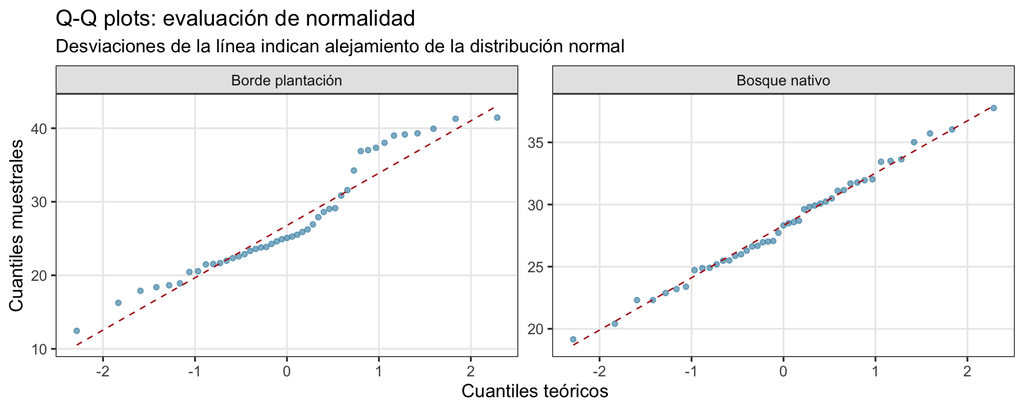

```r
ggplot(datos_peso, aes(sample = peso)) +
  stat_qq(alpha = 0.6, color = "#2E86AB") +
  stat_qq_line(color = "firebrick", linetype = "dashed") +
  facet_wrap(~habitat, scales = "free") +
  labs(
    title = "Q-Q plots: evaluación de normalidad",
    subtitle = "Desviaciones de la línea indican alejamiento de la distribución normal",
    x = "Cuantiles teóricos",
    y = "Cuantiles muestrales"
  )
```

## 3.4 Resumen visual integrado

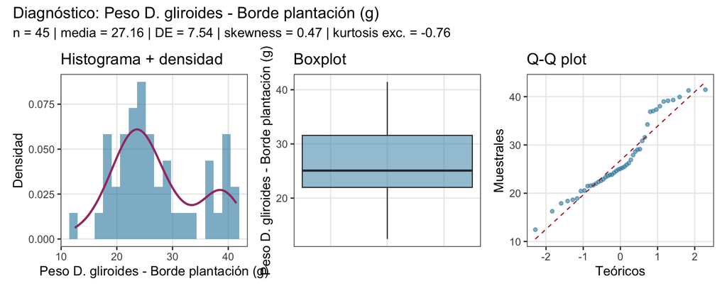

```r
# Función para panel de diagnóstico rápido
diagnostico_distribucion <- function(x, nombre = "Variable") {
  df <- data.frame(x = x)

  p_hist <- ggplot(df, aes(x)) +
    geom_histogram(aes(y = after_stat(density)),
                   bins = 20, fill = "#2E86AB", alpha = 0.6) +
    geom_density(color = "#A23B72", linewidth = 1) +
    labs(title = "Histograma + densidad", x = nombre, y = "Densidad")

  p_box <- ggplot(df, aes(y = x)) +
    geom_boxplot(fill = "#2E86AB", alpha = 0.5, width = 0.3) +
    labs(title = "Boxplot", y = nombre) +
    theme(axis.text.x = element_blank(), axis.ticks.x = element_blank())

  p_qq <- ggplot(df, aes(sample = x)) +
    stat_qq(color = "#2E86AB", alpha = 0.6) +
    stat_qq_line(color = "firebrick", linetype = "dashed") +
    labs(title = "Q-Q plot", x = "Teóricos", y = "Muestrales")

  p_hist + p_box + p_qq +
    plot_annotation(
      title = paste("Diagnóstico:", nombre),
      subtitle = paste0(
        "n = ", length(x),
        " | media = ", round(mean(x), 2),
        " | DE = ", round(sd(x), 2),
        " | skewness = ", round(skewness(x), 2),
        " | kurtosis exc. = ", round(kurtosis(x) - 3, 2)
      )
    )
}

diagnostico_distribucion(peso_borde, "Peso D. gliroides - Borde plantación (g)")
```

# 4 Teorema Central del Límite y Convergencia

## 4.1 Teorema Central del Límite (TCL)

Sea $X_1, X_2, \ldots, X_n$ una muestra aleatoria de una población con media $\mu$ y varianza finita $\sigma^2$. Entonces, a medida que $n \rightarrow \infty$:

$$\bar{X}_n = \frac{1}{n}\sum_{i=1}^{n}
X_i \xrightarrow{d} \mathcal{N}\left(\mu,
\frac{\sigma^2}{n}\right)$$

O equivalentemente:

$$Z_n = \frac{\bar{X}_n - \mu}{\sigma /
\sqrt{n}} \xrightarrow{d} \mathcal{N}(0, 1)$$

**Esto vale sin importar la forma de la distribución original**, siempre que la varianza sea finita.

### 4.1.1 Demostración visual

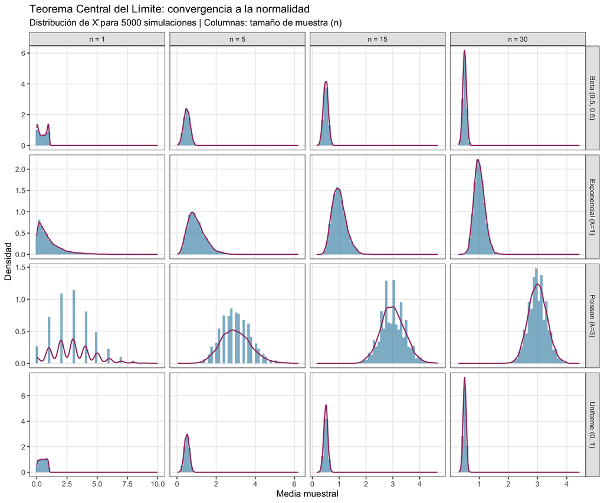

```r
# Demostración del TCL con distintas distribuciones de origen
set.seed(2025)
n_sim <- 5000

# Distribuciones de origen
distribuciones <- list(
  "Exponencial (λ=1)" = function(n) rexp(n, rate = 1),
  "Uniforme (0, 1)"   = function(n) runif(n, 0, 1),
  "Poisson (λ=3)"     = function(n) rpois(n, lambda = 3),
  "Beta (0.5, 0.5)"   = function(n) rbeta(n, 0.5, 0.5)
)

tamanios <- c(1, 5, 15, 30)

# Simulación
tcl_datos <- purrr::map_dfr(names(distribuciones), function(dist_nombre) {
  rfun <- distribuciones[[dist_nombre]]
  purrr::map_dfr(tamanios, function(n) {
    medias <- replicate(n_sim, mean(rfun(n)))
    data.frame(
      media = medias,
      n = paste0("n = ", n),
      distribucion = dist_nombre
    )
  })
})

tcl_datos$n <- factor(tcl_datos$n,
                       levels = paste0("n = ", tamanios))

ggplot(tcl_datos, aes(x = media)) +
  geom_histogram(aes(y = after_stat(density)),
                 bins = 50, fill = "#2E86AB", alpha = 0.6) +
  geom_density(color = "#A23B72", linewidth = 0.8) +
  facet_grid(distribucion ~ n, scales = "free") +
  labs(
    title = "Teorema Central del Límite: convergencia a la normalidad",
    subtitle = paste0(
      "Distribución de X̄ para ", n_sim,
      " simulaciones | Columnas: tamaño de muestra (n)"
    ),
    x = "Media muestral",
    y = "Densidad"
  ) +
  theme(strip.text = element_text(size = 10))
```

> **Observación clave:** Con $n = 30$, la distribución de $\bar{X}$ es prácticamente normal incluso cuando la distribución de origen es fuertemente asimétrica (Exponencial) o bimodal (Beta con parámetros < 1). Sin embargo, para distribuciones muy sesgadas, puede necesitarse $n > 30$.

### 4.1.2 Implicancias para ecología

```r
# Ejemplo práctico: estimación de riqueza de polinizadores
# Distribución de origen: Poisson con λ = 8 especies por sitio

lambda_riq <- 8
tamanos_muestra <- c(3, 5, 10, 20, 50)

tcl_riqueza <- purrr::map_dfr(tamanos_muestra, function(n) {
  medias <- replicate(10000, mean(rpois(n, lambda_riq)))
  data.frame(
    media = medias,
    n = n,
    ee_teorico = sqrt(lambda_riq / n),
    ee_observado = sd(medias)
  )
})

# Comparar error estándar teórico vs observado
ee_comp <- tcl_riqueza %>%
  group_by(n) %>%
  summarise(
    ee_teorico = first(ee_teorico),
    ee_simulado = sd(media),
    .groups = "drop"
  ) %>%
  mutate(across(starts_with("ee"), ~round(.x, 4)))

knitr::kable(ee_comp,
             caption = "Error estándar teórico (σ/√n) vs. simulado")
```

Error estándar teórico (σ/√n) vs. simulado

| n | ee_teorico | ee_simulado |
| --- | --- | --- |
| 3 | 1.6330 | 1.6294 |
| 5 | 1.2649 | 1.2577 |
| 10 | 0.8944 | 0.8905 |
| 20 | 0.6325 | 0.6314 |
| 50 | 0.4000 | 0.4030 |

## 4.2 Tipos de convergencia

Es importante distinguir los distintos modos de convergencia en probabilidad:

### 4.2.1 1. Convergencia en distribución ($\xrightarrow{d}$)

$$F_{X_n}(x) \rightarrow F_X(x) \text{
para todo } x \text{ donde } F_X \text{ es continua}$$

Es la más débil. El TCL es un ejemplo canónico.

### 4.2.2 2. Convergencia en probabilidad ($\xrightarrow{P}$)

$$P(|X_n - X| > \epsilon) \rightarrow 0
\text{ para todo } \epsilon > 0$$

La **Ley (Débil) de los Grandes Números**: $\bar{X}_n \xrightarrow{P} \mu$.

### 4.2.3 3. Convergencia casi segura ($\xrightarrow{c.s.}$)

$$P\left(\lim_{n \rightarrow \infty} X_n =
X\right) = 1$$

La **Ley Fuerte de los Grandes Números**: $\bar{X}_n \xrightarrow{c.s.} \mu$.

### 4.2.4 Relación entre convergencias

$$\text{c.s.} \Rightarrow \text{en
probabilidad} \Rightarrow \text{en distribución}$$

(Las implicaciones inversas no son válidas en general.)

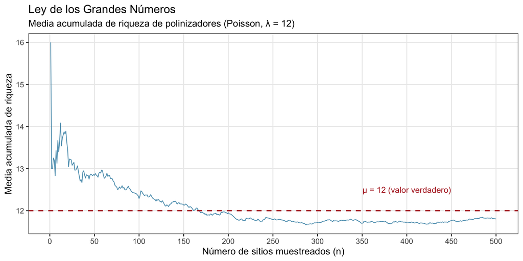

```r
# Visualización de la Ley de los Grandes Números
set.seed(42)

# Simulamos muestreos acumulativos de riqueza de especies
# Distribución real: Poisson(λ = 12)
n_max <- 500
x_lgn <- rpois(n_max, lambda = 12)

media_acum <- cumsum(x_lgn) / seq_along(x_lgn)

df_lgn <- data.frame(
  n = 1:n_max,
  media_acumulada = media_acum
)

ggplot(df_lgn, aes(n, media_acumulada)) +
  geom_line(color = "#2E86AB", alpha = 0.8) +
  geom_hline(yintercept = 12, linetype = "dashed",
             color = "firebrick", linewidth = 0.8) +
  annotate("text", x = n_max * 0.8, y = 12.5,
           label = "μ = 12 (valor verdadero)",
           color = "firebrick", size = 4) +
  labs(
    title = "Ley de los Grandes Números",
    subtitle = "Media acumulada de riqueza de polinizadores (Poisson, λ = 12)",
    x = "Número de sitios muestreados (n)",
    y = "Media acumulada de riqueza"
  ) +
  scale_x_continuous(breaks = seq(0, 500, 50))
```

## 4.3 Error estándar y tamaño muestral

El **error estándar** de la media decrece con $\sqrt{n}$:

$$SE(\bar{X}) =
\frac{\sigma}{\sqrt{n}}$$

Esto tiene implicancias directas para el diseño de muestreo ecológico.

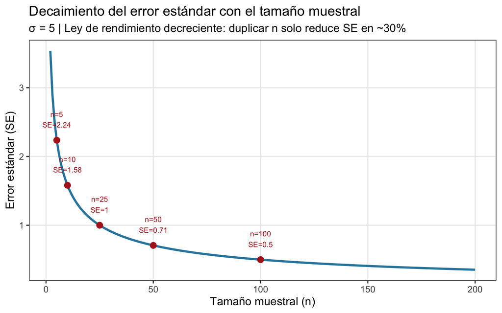

```r
sigma_ejemplo <- 5
n_vals <- 2:200

df_se <- data.frame(
  n = n_vals,
  SE = sigma_ejemplo / sqrt(n_vals)
)

# Líneas de referencia para reducciones clave
n_refs <- c(5, 10, 25, 50, 100)

ggplot(df_se, aes(n, SE)) +
  geom_line(color = "#2E86AB", linewidth = 1.2) +
  geom_point(data = df_se %>% filter(n %in% n_refs),
             color = "firebrick", size = 3) +
  geom_text(data = df_se %>% filter(n %in% n_refs),
            aes(label = paste0("n=", n, "\nSE=", round(SE, 2))),
            vjust = -0.8, size = 3, color = "firebrick") +
  labs(
    title = "Decaimiento del error estándar con el tamaño muestral",
    subtitle = paste0("σ = ", sigma_ejemplo,
                      " | Ley de rendimiento decreciente: ",
                      "duplicar n solo reduce SE en ~30%"),
    x = "Tamaño muestral (n)",
    y = "Error estándar (SE)"
  )
```

> **Consejo práctico:** Aumentar el tamaño muestral de 25 a 100 (4x) solo reduce el SE a la mitad. En diseños de muestreo ecológico, a menudo es más eficiente invertir en estratificación o en reducir la variabilidad dentro de las unidades que en simplemente aumentar $n$.

# 5 Ejercicios Propuestos

## 5.1 Ejercicio 1: Probabilidad condicional y Bayes

En un estudio de polinización en el desierto florido, se sabe que:

- El 60% de las visitas florales son de abejas nativas y el 40% de *Apis mellifera*.
- La probabilidad de polinización efectiva dado una visita de abeja nativa es 0.75.
- La probabilidad de polinización efectiva dado una visita de *Apis* es 0.30.
1. ¿Cuál es la probabilidad de que una visita cualquiera resulte en polinización efectiva?
2. Si observamos polinización efectiva, ¿cuál es la probabilidad de que el visitante haya sido una abeja nativa?

## 5.2 Ejercicio 2: Selección de distribución

Usted tiene los siguientes conjuntos de datos ecológicos. Para cada uno, justifique qué distribución utilizaría y por qué:

1. Número de parásitos por hospedero (media = 3.2, varianza = 18.7).
2. Proporción de cobertura vegetal por cuadrante (valores entre 0 y 1).
3. Peso seco de biomasa foliar (g) de plantas de una misma especie.
4. Presencia/ausencia de *D. gliroides* en 50 cámaras trampa durante una noche.

## 5.3 Ejercicio 3: Estadígrafos y diagnóstico

Cargue un conjunto de datos ecológicos de su elección y aplique la función `diagnostico_distribucion()` definida en esta clase. Interprete los resultados en términos de:

- ¿Es apropiado usar la media como medida de tendencia central?
- ¿Qué medida de dispersión es más informativa?
- ¿Qué distribución teórica se ajustaría mejor?

## 5.4 Ejercicio 4: TCL en acción

Simule 10,000 medias muestrales de tamaño $n = 5, 10, 30, 100$ a partir de una distribución Binomial Negativa con $\mu = 4$ y $\theta = 0.8$ (fuertemente sobredispersa). ¿A partir de qué $n$ la distribución de $\bar{X}$ se aproxima razonablemente a una normal?

# 6 Lecturas Recomendadas

- **Bolker, B.M.** (2008). *Ecological Models and Data in R*. Princeton University Press. Capítulos 4-5.
- **Gotelli, N.J. & Ellison, A.M.** (2013). *A Primer of Ecological Statistics*. 2nd ed. Sinauer. Capítulos 2-4.
- **Casella, G. & Berger, R.L.** (2002). *Statistical Inference*. 2nd ed. Duxbury. Capítulos 1-5 (para profundizar en teoría).